# Statistical Rethinking Chapter 9

### Non identifiable parameters

With highly correlated predictors there is a problem of non-identifiable parameters.

To construct similar non-identifiable situations, we simulate 100 obs from a Gaussian dist with mean zero and sd 1.

```r
set.seed(41)
y <- rnorm(100, mean = 0, sd = 1)
```

Then we fit the following model:

$$\begin{align}
y_i &\sim Normal(\mu, \sigma) \\
\mu &= \alpha_1 + \alpha_2 \\
\alpha_1 &\sim Normal(0, 1000) \\
\alpha_2 &\sim Normal(0, 1000) \\
\sigma &\sim Exponential(1)
\end{align}$$

$\alpha_1$ and $\alpha_2$ can’t be identified, only their sum can be identified which should be zero after estimation.

```r
set.seed(384)
m9.4 <- ulam(
  alist(
    y ~ dnorm(mu, sigma),
    mu <- a1 + a2,
    a1 ~ dnorm(0, 1000),
    a2 ~ dnorm(0, 1000),
    sigma ~ dexp(1)
  ), data = list(y = y), chains = 3
)
```

```
## Warning: Tail Effective Samples Size (ESS) is too low, indicating posterior variances and tail quantiles may be unreliable.
## Running the chains for more iterations may help. See
## http://mc-stan.org/misc/warnings.html#tail-ess
```

```r
precis(m9.4)
```

```
##             mean           sd        5.5%      94.5%     n_eff    Rhat4
## a1    -37.528345 430.02223526 -605.995946 677.529388  1.853644 3.346379
## a2     37.716575 430.02596973 -677.288723 606.263939  1.853613 3.346438
## sigma   1.023165   0.06499162    0.921962   1.133209 16.062994 1.297504
```

Estimates seem suspicious, sd are very wide, n_eff is very small, and Rhat is high too. This is since we can’t simultaneously estimate a1 and a2, but only their sum.

```
## [1] 1000
## [1] 1
## [1] 1000
```

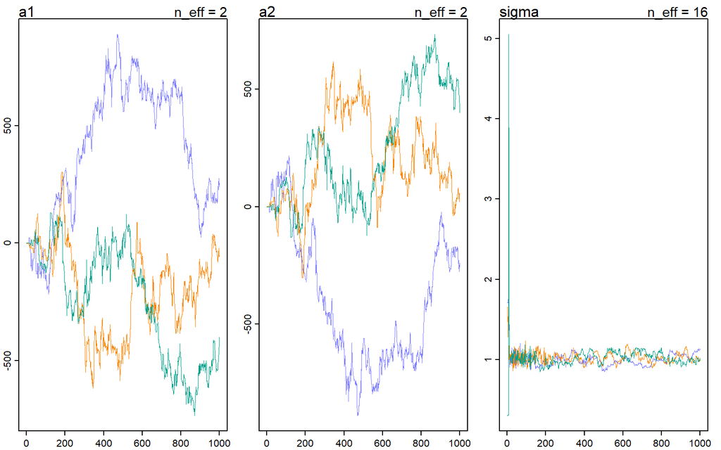

```r
traceplot(m9.4)
```

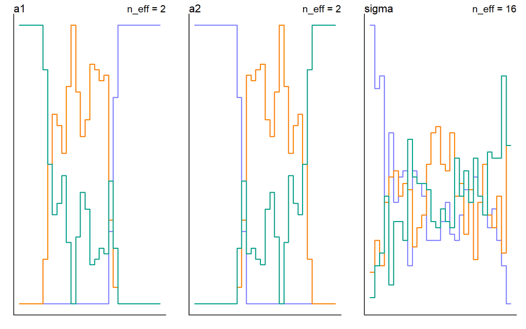

```r
trankplot(m9.4)
```

Chains neither stationary nor mixing nor converging. Seeing chains like this implies don’t use these chains.

Again weakly regularizing priors is helpful.

```r
m9.5 <- ulam(
  alist(
    y ~ dnorm(mu, sigma),
    mu <- a1 + a2,
    a1 ~ dnorm(0, 10),
    a2 ~ dnorm(0, 10),
    sigma ~ dexp(1)
  ), data = list(y = y), chains = 3
)
precis(m9.5)
```

```
##             mean         sd        5.5%     94.5%    n_eff    Rhat4
## a1     0.3261916 6.99143112 -11.2516530 10.758395 252.7479 1.013808
## a2    -0.1309445 6.98726504 -10.5498784 11.398724 252.4394 1.013793
## sigma  1.0341261 0.07176822   0.9262933  1.152745 490.5554 1.003023
```

Much better now. a1 and a2 still can’t be identified separately, but the results are not as terrible as before.

```
## [1] 1000
## [1] 1
## [1] 1000
```

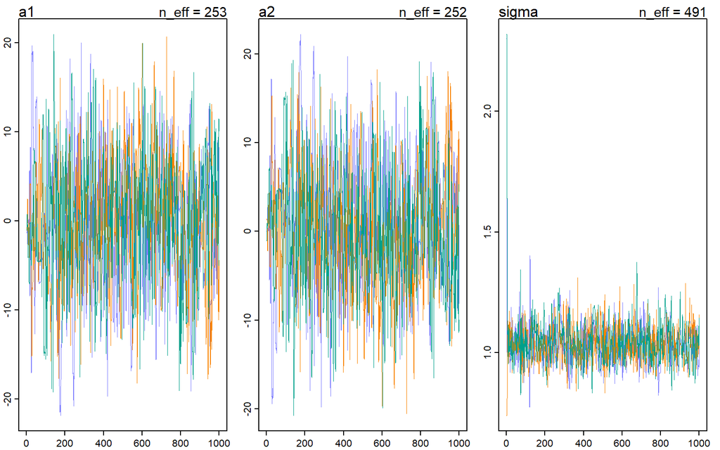

```r
traceplot(m9.5)
```

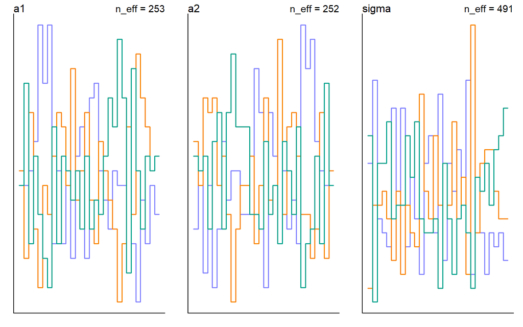

```r
trankplot(m9.5)
```

much better here too. seems stationary, and mixing well.